# ECO-MRIO-SFC Model: Flexible Version Documentation

Oriol Vallès Codina

2024-07-17

# Introduction

At the moment, my computation of the Jacobian returns a non-invertible matrix. This may well be due to the existence of redundant equations or variables that do not change over time (should be considered exogenous). An issue is that the state vector that is passed to the Jacobian computation includes the previous time period $\{y_{t-1}, y_t\}$ and this may yield problems: Jacobian is then of dimension $2n \times 2n$, where $n = 663$ is the current number of variables.

# Initialization

The initial values and variables are loaded from the file `initial_values_july10.xlsx` stored in variable `identif` in a different structure as before.

```r
# Load Auxiliary Functions
directory <- ''
source(paste0(directory, 'functions/auxiliary_flexible.R')) # load.new.init, auxiliary labeling functions, plotting function

# Load Initial Values
identif <- paste0(directory, 'data/initial_values_july10.xlsx')
initial <- load.new.init(identif)

# Load Models
source(paste0(directory, "functions/run_new_model.R")) # function run.new.model(initial.values, model.equations)
source(paste0(directory, "functions/MVP_model.R")) # model equations
```

# Description of the `initial` Object

The `initial` object contains the following elements:

```r
names(initial)
```

```
##  [1] "variables"  "parameters" "A.matrix"   "init.table" "identif"
##  [6] "countries"  "sectors"    "N"          "K"          "zlabs"
```

- `init.table`, which is the initial state vector (computed from `variables`) of size 663,
- `identif`, which saves the name of the Excel file for reference and documentation purposes: data/initial_values_july10.xlsx,
- `countries`, the country labels that are taken from the $A$ matrix row names (left to the dot `.`): EU, RoW
- `sectors`, the industry labels that are taken from the $A$ matrix row names (right to the dot `.`): Manufacturing, Agriculture, Services, Waste, Recycling
- `N`, the number of countries (a scalar), $N = 2$,
- `K`, the number of industries in each country (a vector), $K = 5, 5$, and
- `zlabs`, auxiliary country labels: zlabs = Z1, Z2.

## Variables

`variables` has 3 elements, `global`, `aggregate` and `industry`:

```r
str(initial$variables)
```

```
## List of 3
##  $ global   :'data.frame':   1 obs. of  5 variables:
##   ..$ variable: chr "temp"
##   ..$ name    : chr "Atmospheric Temperature"
##   ..$ area    : chr "global"
##   ..$ industry: chr "aggregate"
##   ..$ t1      : num 0
##  $ aggregate:'data.frame':   101 obs. of  7 variables:
##   ..$ variable: chr [1:101] "a_d" "a_s" "af" "b_b" ...
##   ..$ name    : chr [1:101] "Demand for Advances" "Central Bank Advances: Supply" "Amortization Funds" "Holdings of Bills" ...
##   ..$ industry: chr [1:101] "aggregate" "aggregate" "aggregate" "aggregate" ...
##   ..$ dynamic : chr [1:101] "endogenous" "endogenous" "endogenous" "endogenous" ...
##   ..$ type    : chr [1:101] "commercial.banks" "govt.central.bank" "investment" "commercial.banks" ...
##   ..$ Z1      : num [1:101] 0 0 0 0 0 0 0 0 0 0 ...
##   ..$ Z2      : num [1:101] 0 0 0 0 0 0 0 0 0 0 ...
##  $ industry :'data.frame':   92 obs. of  10 variables:
##   ..$ variable: chr [1:92] "beta" "beta" "d" "d" ...
##   ..$ name    : chr [1:92] "Share in Household Consumption" "Share in Household Consumption" "Final Demand in Real Terms" "Final Demand in Real Terms" ...
##   ..$ area    : chr [1:92] "Z1" "Z2" "Z1" "Z2" ...
##   ..$ dynamic : chr [1:92] "exogenous" "exogenous" "endogenous" "endogenous" ...
##   ..$ type    : chr [1:92] NA NA "production" "production" ...
##   ..$ 1       : num [1:92] 0.29 0.27 0 0 0 0 0 0 0.7 0.7 ...
##   ..$ 2       : num [1:92] 0.03 0.05 0 0 0 0 0 0 0.7 0.7 ...
##   ..$ 3       : num [1:92] 0.68 0.68 0 0 0 0 0 0 0.7 0.7 ...
##   ..$ 4       : num [1:92] 0 0 0 0 0 0 0 0 0.7 0.7 ...
##   ..$ 5       : num [1:92] 0 0 0 0 0 0 0 0 0.6 0.6 ...
```

### Aggregate (Country-Level) Variables

The model features 101 aggregate variables.

```r
kable(initial$variables$aggregate, booktabs = TRUE, digits = 2) %>% scroll_box(width = "1000px", height = "200px")
```

| variable | name | industry | dynamic | type | Z1 | Z2 |
| --- | --- | --- | --- | --- | --- | --- |
| a_d | Demand for Advances | aggregate | endogenous | commercial.banks | 0.00 | 0.00 |
| a_s | Central Bank Advances: Supply | aggregate | endogenous | govt.central.bank | 0.00 | 0.00 |
| af | Amortization Funds | aggregate | endogenous | investment | 0.00 | 0.00 |
| b_b | Holdings of Bills | aggregate | endogenous | commercial.banks | 0.00 | 0.00 |
| b_cb | Central Bank Holdings of Domestic Bills | aggregate | endogenous | govt.central.bank | 0.00 | 0.00 |
| b_cb_d_Z2 | Z2 Bills held by Z1 Central Bank | aggregate | endogenous | govt.central.bank | 0.00 | 0.00 |
| b_cb_s_Z2 | Supply of Z2 bills to Z1 Central Bank | aggregate | endogenous | govt.central.bank | 0.00 | 0.00 |
| b_h_Z1 | Private Demand for Z1 Bills | aggregate | endogenous | portfolio.choices | 0.00 | 0.00 |
| b_h_Z2 | Private Demand for Z2 Bills | aggregate | endogenous | portfolio.choices | 0.00 | 0.00 |
| b_s | Supply of Government Bills (Government Debt) | aggregate | endogenous | govt.central.bank | 0.00 | 0.00 |
| b_s_Z1 | Supply of Z1 Bills to Households | aggregate | endogenous | govt.central.bank | 0.00 | 0.00 |
| b_s_Z2 | Supply of Z2 Bills to Households | aggregate | endogenous | govt.central.bank | 0.00 | 0.00 |
| c | Total Real Consumption | aggregate | endogenous | households | 0.00 | 0.00 |
| cab | Current Account Balance | aggregate | endogenous | balance.of.payments | 0.00 | 0.00 |
| co2_cum | Cumulative CO2 Emissions (Alternative Method) | aggregate | endogenous | ecological | 0.00 | 0.00 |
| da | Depreciation Allowance in Real Terms | aggregate | endogenous | investment | 0.00 | 0.00 |
| da_g | Government Depreciation Allowance in Real Terms | aggregate | endogenous | govt.central.bank | 0.00 | 0.00 |
| dis | Discarded Socioeconomic Stock | aggregate | endogenous | ecological | 0.00 | 0.00 |
| div | Total Net Dividends Received by Households | aggregate | endogenous | investment | 0.00 | 0.00 |
| div_h1 | Total Net Dividends Received by Households | aggregate | endogenous | investment | 0.00 | 0.00 |
| dxr | Time Difference of the Exchange Rate | aggregate | endogenous | balance.of.payments | 0.00 | 0.00 |
| e_h_Z1 | Z1 Shares Held by Households (Denominated in Local Currency) | aggregate | endogenous | portfolio.choices | 0.00 | 0.00 |
| e_h_Z2 | Z2 Shares held by Households (Denominated in Local Currency) | aggregate | endogenous | portfolio.choices | 0.00 | 0.00 |
| e_s | Stock of Shares Issued by Private Firms | aggregate | endogenous | investment | 0.00 | 0.00 |
| e_s_Z1 | Z1 Shares Supplied to Z2 Households (Denominated in Z1 Currency) | aggregate | endogenous | investment | 0.00 | 0.00 |
| e_s_Z2 | Z2 Shares Supplied to Z1 Households (Denominated in Z2 Currency) | aggregate | endogenous | investment | 0.00 | 0.00 |
| emis | Annual CO2 Emissions | aggregate | endogenous | ecological | 0.00 | 0.00 |
| en | Energy Required for Production | aggregate | endogenous | ecological | 0.00 | 0.00 |
| f_b | Bank Profit | aggregate | endogenous | commercial.banks | 0.00 | 0.00 |
| f_cb | Central Bank Profits | aggregate | endogenous | govt.central.bank | 0.00 | 0.00 |

[output cut: 71 more lines]

### Industry-level Variables

The model features 92 industry variables.

```r
kable(initial$variables$industry, booktabs = TRUE, digits = 2) %>% scroll_box(width = "1000px", height = "200px")
```

| variable | name | area | dynamic | type | 1 | 2 | 3 | 4 | 5 |
| --- | --- | --- | --- | --- | --- | --- | --- | --- | --- |
| beta | Share in Household Consumption | Z1 | exogenous | NA | 0.29 | 0.03 | 0.68 | 0.00 | 0.00 |
| beta | Share in Household Consumption | Z2 | exogenous | NA | 0.27 | 0.05 | 0.68 | 0.00 | 0.00 |
| d | Final Demand in Real Terms | Z1 | endogenous | production | 0.00 | 0.00 | 0.00 | 0.00 | 0.00 |
| d | Final Demand in Real Terms | Z2 | endogenous | production | 0.00 | 0.00 | 0.00 | 0.00 | 0.00 |
| dc | Durable Consumption Goods | Z1 | endogenous | ecological | 0.00 | 0.00 | 0.00 | 0.00 | 0.00 |
| dc | Durable Consumption Goods | Z2 | endogenous | ecological | 0.00 | 0.00 | 0.00 | 0.00 | 0.00 |
| emis_j | Annual CO2 Emissions | Z1 | endogenous | ecological | 0.00 | 0.00 | 0.00 | 0.00 | 0.00 |
| emis_j | Annual CO2 Emissions | Z2 | endogenous | ecological | 0.00 | 0.00 | 0.00 | 0.00 | 0.00 |
| eps | Energy Intensity | Z1 | exogenous | NA | 0.70 | 0.70 | 0.70 | 0.70 | 0.60 |
| eps | Energy Intensity | Z2 | exogenous | NA | 0.70 | 0.70 | 0.70 | 0.70 | 0.60 |
| eps_en | Energy Intensity of Output | Z1 | exogenous | NA | 7.00 | 6.00 | 5.00 | 8.00 | 4.00 |
| eps_en | Energy Intensity of Output | Z2 | exogenous | NA | 7.00 | 6.00 | 5.00 | 8.00 | 4.00 |
| eta | Share of Imports | Z1 | exogenous | NA | 0.63 | 0.06 | 0.31 | 0.00 | 0.00 |
| eta | Share of Imports | Z2 | exogenous | NA | 0.67 | 0.01 | 0.32 | 0.00 | 0.00 |
| eta_en | Shares of Renewable Energy in Total Energy | Z1 | exogenous | NA | 0.14 | 0.14 | 0.14 | 0.14 | 0.20 |
| eta_en | Shares of Renewable Energy in Total Energy | Z2 | exogenous | NA | 0.14 | 0.14 | 0.14 | 0.14 | 0.14 |
| g_pop | Growth Rate of Native Labour Force | Z1 | exogenous | NA | 0.00 | 0.00 | 0.00 | 0.00 | 0.00 |
| g_pop | Growth Rate of Native Labour Force | Z2 | exogenous | NA | 0.00 | 0.00 | 0.00 | 0.00 | 0.00 |
| gamma_imm_0 | Autonomous Immigration from Z1 to Z2 (by industry) | Z1 | exogenous | NA | 0.00 | 0.00 | 0.00 | 0.00 | 0.00 |
| gamma_imm_0 | Autonomous Immigration from Z2 to Z1 (by industry) | Z2 | exogenous | NA | 0.00 | 0.00 | 0.00 | 0.00 | 0.00 |
| gamma_imm_1 | Immigration from Z1 to Z2 (by industry) Depending on Unemployment Rate | Z1 | exogenous | NA | 0.00 | 0.00 | 0.00 | 0.00 | 0.00 |
| gamma_imm_1 | Immigration from Z2 to Z1 (by industry) Depending on Unemployment Rate | Z2 | exogenous | NA | 0.00 | 0.00 | 0.00 | 0.00 | 0.00 |
| gamma_imm_2 | Immigration from Z1 to Z2 (by industry) Depending on Wage Gap | Z1 | exogenous | NA | 0.00 | 0.00 | 0.00 | 0.00 | 0.00 |
| gamma_imm_2 | Immigration from Z2 to Z1 (by industry) Depending on Wage Gap | Z2 | exogenous | NA | 0.00 | 0.00 | 0.00 | 0.00 | 0.00 |
| gamma_pop | Adjustment Speed of Labor Force | Z1 | exogenous | NA | 0.15 | 0.15 | 0.15 | 0.15 | 0.15 |
| gamma_pop | Adjustment Speed of Labor Force | Z2 | exogenous | NA | 0.15 | 0.15 | 0.15 | 0.15 | 0.15 |
| gamma_x | Market Price Coefficient | Z1 | exogenous | NA | 0.00 | 0.00 | 0.00 | 0.00 | 0.00 |
| gamma_x | Market Price Coefficient | Z2 | exogenous | NA | 0.00 | 0.00 | 0.00 | 0.00 | 0.00 |
| gammaA1 | Government Spending-Sensitivity of Speed of Adjustment to CE | Z1 | exogenous | NA | 0.00 | 0.00 | 0.00 | 0.00 | 0.00 |
| gammaA1 | Government Spending-Sensitivity of Speed of Adjustment to CE | Z2 | exogenous | NA | 0.00 | 0.00 | 0.00 | 0.00 | 0.00 |

[output cut: 62 more lines]

### init.table

Function `load.new.init` saves the 3 elements, `global`, `aggregate` and `industry`, into the useful data frame `init.table` with all variable labels as in the old code and their corresponding initial values. Hence this is the initial state vector.

```r
kable(initial$init.table, booktabs = TRUE, digits = 2) %>% scroll_box(width = "800px", height = "200px")
```

| label | value | dynamic | type |
| --- | --- | --- | --- |
| temp | 0.00 | endogenous | NA |
| Z1_a_d | 0.00 | endogenous | commercial.banks |
| Z1_a_s | 0.00 | endogenous | govt.central.bank |
| Z1_af | 0.00 | endogenous | investment |
| Z1_b_b | 0.00 | endogenous | commercial.banks |
| Z1_b_cb | 0.00 | endogenous | govt.central.bank |
| Z1_b_cb_d_Z2 | 0.00 | endogenous | govt.central.bank |
| Z1_b_cb_s_Z2 | 0.00 | endogenous | govt.central.bank |
| Z1_b_h_Z1 | 0.00 | endogenous | portfolio.choices |
| Z1_b_h_Z2 | 0.00 | endogenous | portfolio.choices |
| Z1_b_s | 0.00 | endogenous | govt.central.bank |
| Z1_b_s_Z1 | 0.00 | endogenous | govt.central.bank |
| Z1_b_s_Z2 | 0.00 | endogenous | govt.central.bank |
| Z1_c | 0.00 | endogenous | households |
| Z1_cab | 0.00 | endogenous | balance.of.payments |
| Z1_co2_cum | 0.00 | endogenous | ecological |
| Z1_da | 0.00 | endogenous | investment |
| Z1_da_g | 0.00 | endogenous | govt.central.bank |
| Z1_dis | 0.00 | endogenous | ecological |
| Z1_div | 0.00 | endogenous | investment |
| Z1_div_h1 | 0.00 | endogenous | investment |
| Z1_dxr | 0.00 | endogenous | balance.of.payments |
| Z1_e_h_Z1 | 0.00 | endogenous | portfolio.choices |
| Z1_e_h_Z2 | 0.00 | endogenous | portfolio.choices |
| Z1_e_s | 0.00 | endogenous | investment |
| Z1_e_s_Z1 | 0.00 | endogenous | investment |
| Z1_e_s_Z2 | 0.00 | endogenous | investment |
| Z1_emis | 0.00 | endogenous | ecological |
| Z1_en | 0.00 | endogenous | ecological |
| Z1_f_b | 0.00 | endogenous | commercial.banks |

[output cut: 633 more lines]

Its dimension is the number of global variables 1 plus the number of aggregate variables 101 times the number of countries 2 plus the number of industry variables 46 times the number of countries 2 times the number of industries 5:

```r
nrow(initial$variables$global) + nrow(initial$variables$aggregate) * initial$N + nrow(initial$variables$industry) * unique(initial$K)
```

```
## [1] 663
```

## Parameters

At the moment, 152 parameters are saved in the old way, but using the same structure as for the new variables may be more convenient:

```r
kable(initial$parameters, booktabs = T, digits = 2) %>% scroll_box(width = "500px", height = "200px")
```

|  | value |
| --- | --- |
| fnc | 0.50 |
| max.iterations | 100.00 |
| nPeriods | 100.00 |
| tolerance | 0.00 |
| consistency.threshold | 0.01 |
| par_xr | 0.15 |
| shock | 0.00 |
| t.shock | 70.00 |
| more.input | 1.15 |
| less.input | 0.95 |
| reduction | 0.60 |
| sigma_en | 0.00 |
| sigma_mat | 0.00 |
| tcre | 0.00 |
| Z1_alpha1 | 0.70 |
| Z1_alpha2 | 0.40 |
| Z1_alpha3 | 0.40 |
| Z1_beta_e | 0.07 |
| Z1_beta10 | 0.29 |
| Z1_beta20 | 0.03 |
| Z1_beta30 | 0.68 |
| Z1_beta31 | 0.00 |
| Z1_beta32 | 0.00 |
| Z1_ce | 0.00 |
| Z1_delta | 0.25 |
| Z1_delta_g | 0.00 |
| Z1_g_g | 0.00 |
| Z1_gamma | 0.15 |
| Z1_gamma_mu | 0.20 |
| Z1_gamma_p1 | 0.50 |

[output cut: 122 more lines]

## $A$ Matrix

Importantly, the column names of the $A$ matrix contained in `identif` determine the country and industry labels in the whole model, following the grammar `country_label.industry_label`:

```r
kable(initial$A.matrix, booktabs = TRUE, digits = 4)
```

|  | EU.Manufacturing | EU.Agriculture | EU.Services | EU.Waste | EU.Recycling | RoW.Manufacturing | RoW.Agriculture | RoW.Services | RoW.Waste | RoW.Recycling |
| --- | --- | --- | --- | --- | --- | --- | --- | --- | --- | --- |
| EU.Manufacturing | 0.3159 | 0.1899 | 0.0633 | 0.1203 | 0.2553 | 0.0116 | 0.0041 | 0.0034 | 0.0038 | 0.0168 |
| EU.Agriculture | 0.0235 | 0.0836 | 0.0016 | 0.0009 | 0.0016 | 0.0003 | 0.0006 | 0.0001 | 0.0002 | 0.0001 |
| EU.Services | 0.1782 | 0.1481 | 0.2573 | 0.2406 | 0.2224 | 0.0036 | 0.0019 | 0.0061 | 0.0046 | 0.0063 |
| EU.Waste | 0.0037 | 0.0041 | 0.0027 | 0.1262 | 0.0127 | 0.0001 | 0.0002 | 0.0000 | 0.0003 | 0.0001 |
| EU.Recycling | 0.0218 | 0.0026 | 0.0015 | 0.0105 | 0.0770 | 0.0007 | 0.0000 | 0.0000 | 0.0001 | 0.0027 |
| RoW.Manufacturing | 0.0781 | 0.0326 | 0.0096 | 0.0136 | 0.0899 | 0.4477 | 0.1265 | 0.0939 | 0.1433 | 0.3057 |
| RoW.Agriculture | 0.0028 | 0.0162 | 0.0004 | 0.0003 | 0.0011 | 0.0394 | 0.1220 | 0.0053 | 0.0055 | 0.0068 |
| RoW.Services | 0.0131 | 0.0066 | 0.0204 | 0.0151 | 0.0138 | 0.1495 | 0.1376 | 0.2616 | 0.1978 | 0.2113 |
| RoW.Waste | 0.0002 | 0.0003 | 0.0001 | 0.0018 | 0.0002 | 0.0030 | 0.0069 | 0.0042 | 0.0542 | 0.0057 |
| RoW.Recycling | 0.0003 | 0.0000 | 0.0000 | 0.0000 | 0.0010 | 0.0035 | 0.0025 | 0.0001 | 0.0006 | 0.0760 |

Circular economy matrix $B$ is computed from the $A$ matrix using parameters `more.input` and `less.input` to obtain the new coefficients from the old ones.

## Auxiliary Functions

Auxiliary functions `z.lab`, `zk.lab` and `zk.sum` perform actions on the variable labels so model computations can be written in a simpler way at the country level and at the industry level.

# Run New Model Baseline

Function `run.new.model` loads initial values `initial` as first argument and runs the model equations at time period $t$ of the second argument as in `mvp.model` (for instance stored in `MVP_model.R`), in this case using the Gauss-Seidel solver that checks convergence to a stable solution at each iteration:

```r
initial$parameters['shock', ] <- 0
# baseline <- run.new.model(initial, mvp.model)
# saveRDS(baseline, paste0(directory, 'data/baseline.RDS'))
baseline <- readRDS(paste0(directory, 'data/baseline.RDS'))
```

The old model run globally took ~13 secs, while the new model run globally took ~30 secs. However, run as a function, the old model takes ~1.8 min and the new model takes ~33 secs.

Model equations are adapted, with some minor changes documented in the file `run.new.model`, from the file `Model_rev (JBF_Revised Feb_with public Investment)_adapted`. Now all industry-level and country-level variables are saved into a single vector `sim`. Parameters (scalars in the old code) are saved into a single vector `para`. In the old code, we could distinguish between demand-led and actual industry-level variables, which is no longer the case (all are actual).

```r
dim(baseline$simulation)
```

```
##          nPeriods
##      663      100
```

```r
# Aggregate Nominal Income for Z1
baseline$simulation['Z1_yn', ]
```

```
##   [1]    0.0000  490.3366  591.9880  739.3032  838.6049  916.8859  979.2509
##   [8] 1028.3682 1066.4424 1093.8563 1114.9826 1130.1061 1140.4043 1146.8822
##  [15] 1150.3842 1151.6106 1151.1356 1149.4262 1146.8593 1143.7351 1140.2893
##  [22] 1136.7041 1133.1170 1129.6290 1126.3118 1123.2130 1120.3618 1117.7726
##  [29] 1115.4488 1113.3901 1111.5925 1110.0352 1108.6977 1107.5592 1106.5985
##  [36] 1105.7954 1105.1303 1104.5852 1104.1432 1103.7891 1103.5092 1103.2914
##  [43] 1103.1251 1103.0010 1102.9112 1102.8490 1102.8086 1102.7852 1102.7748
##  [50] 1102.7742 1102.7805 1102.7918 1102.8063 1102.8226 1102.8398 1102.8570
##  [57] 1102.8737 1102.8894 1102.9040 1102.9173 1102.9291 1102.9395 1102.9486
##  [64] 1102.9563 1102.9627 1102.9680 1102.9723 1102.9756 1102.9781 1102.9799
##  [71] 1102.9810 1102.9816 1102.9817 1102.9815 1102.9809 1102.9801 1102.9791
##  [78] 1102.9779 1102.9766 1102.9751 1102.9736 1102.9721 1102.9705 1102.9689
##  [85] 1102.9674 1102.9658 1102.9642 1102.9627 1102.9612 1102.9598 1102.9583
##  [92] 1102.9569 1102.9556 1102.9543 1102.9530 1102.9518 1102.9506 1102.9494
##  [99] 1102.9483 1102.9472
```

```r
# Employment of Industry 4, Area Z2
baseline$simulation['Z2_n_j-4', ]
```

```
##   [1]   0.0000 291.3037 344.6426 444.3035 511.3953 566.0177 610.4198 646.1545
##   [9] 674.4903 696.8758 713.7682 726.2877 735.2147 741.2305 744.9191 746.7775
##  [17] 747.2232 746.6045 745.2095 743.2733 740.9856 738.4970 735.9251 733.3596
##  [25] 730.8672 728.4956 726.2770 724.2314 722.3692 720.7191 719.2738 718.0187
##  [33] 716.9373 716.0127 715.2281 714.5674 714.0156 713.5585 713.1834 712.8785
##  [41] 712.6333 712.4384 712.2857 712.1679 712.0788 712.0132 711.9664 711.9347
##  [49] 711.9149 711.9042 711.9004 711.9018 711.9069 711.9145 711.9237 711.9337
##  [57] 711.9440 711.9543 711.9642 711.9734 711.9820 711.9897 711.9966 712.0026
##  [65] 712.0079 712.0123 712.0161 712.0191 712.0216 712.0235 712.0250 712.0260
##  [73] 712.0266 712.0270 712.0270 712.0269 712.0265 712.0260 712.0254 712.0247
##  [81] 712.0239 712.0230 712.0221 712.0212 712.0202 712.0193 712.0183 712.0173
##  [89] 712.0164 712.0155 712.0145 712.0136 712.0128 712.0119 712.0111 712.0103
##  [97] 712.0095 712.0087 712.0080 712.0073
```

# Auxiliary Labeling Examples

Country-level consumption `c` for both regions at time 10 is obtained using `z.lab`:

```r
baseline$simulation[z.lab('c'), 10]
```

```
##      Z1_c      Z2_c
##  765.3057 2460.8580
```

Industry-level value-added `va_j` at time 40 is obtained using `zk.lab`:

```r
baseline$simulation[zk.lab('va_j'), 40]
```

```
##   Z1_va_j-1   Z1_va_j-2   Z1_va_j-3   Z1_va_j-4   Z1_va_j-5   Z2_va_j-1
##  301.390198   26.700052  875.283997    4.239071    8.460927 1073.651027
##   Z2_va_j-2   Z2_va_j-3   Z2_va_j-4   Z2_va_j-5
##  211.996619 2596.300747   19.788594    5.634377
```

which can be summed by country:

```r
zk.sum(baseline$simulation[zk.lab('va_j'), 40])
```

```
##       Z1       Z2
## 1216.074 3907.371
```

# Example Baseline Visualization

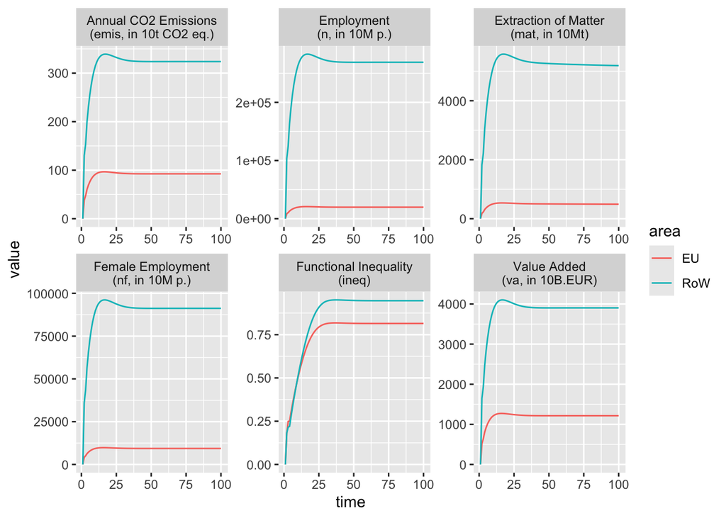

```r
selected <- c('va', 'n', 'nf', 'ineq', 'emis', 'mat')

p.selected <- plot.vars(baseline, selected)
```

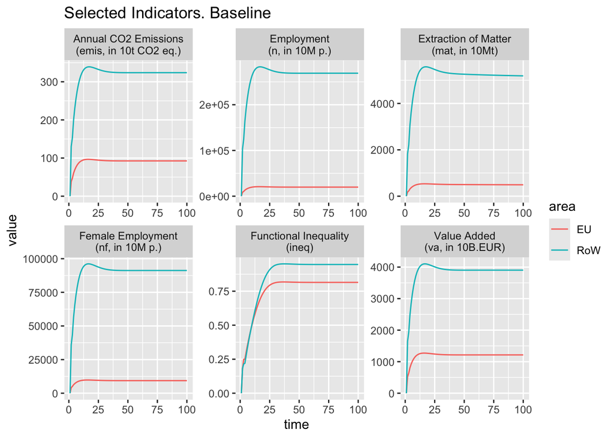

```r
p.selected + ggtitle('Selected Indicators. Baseline')
```

# Shock Example

## Simple Visualization

This is a simple visualization of shock 1.

```r
initial$parameters['shock', ] <- 1 # shock 1
shock.run <- run.new.model(initial, mvp.model)
```

```
## Time difference of 30.92485 secs
```

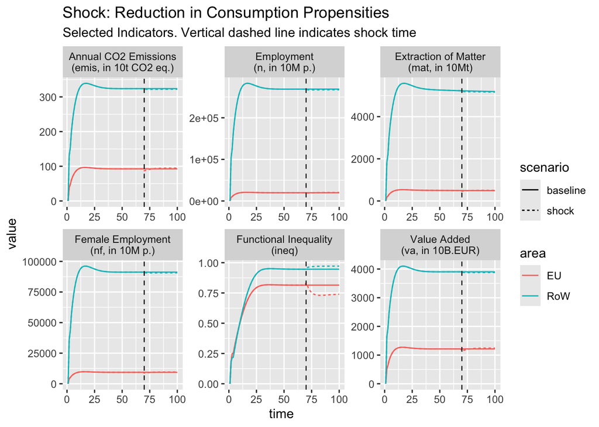

```r
shock.title <- paste0('Shock: Reduction in Consumption Propensities')

df <- shock.long.new(baseline, shock.run)

# Selected Vars to plot
p.selected.vars <- filter(df, variable %in% selected) %>%
    ggplot(aes(x = time, y = value, color = area, linetype = scenario)) + facet_wrap(~ name, scales = 'free') + geom_line() +
    geom_vline(xintercept = initial$parameters['t.shock', ], linetype = 'dashed', linewidth = .4) +
    labs(title = shock.title, subtitle = 'Selected Indicators. Vertical dashed line indicates shock time')

p.selected.vars
```

## Scaled Visualization

This is a scaled visualization of shock 1.

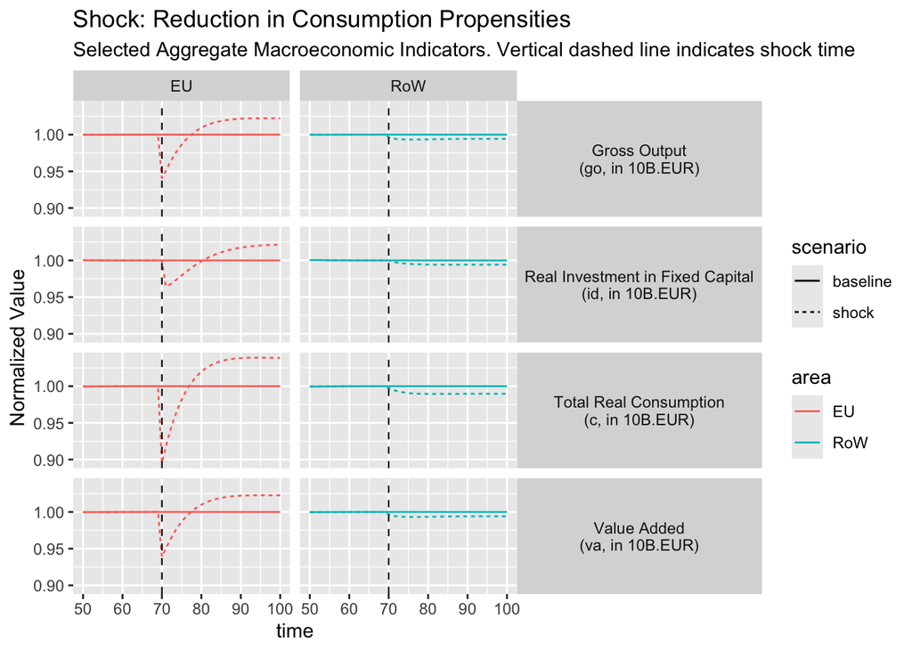

```r
# Variable Selection
macro.vars <- c('c', 'va', 'go','id')
external.vars <- c('cab', 'gdef', 'tb', 'nimp')
social.vars <- c('n', 'nf', 'ineq', 'pa')

# Time Period Selection
t.shock <- initial$parameters['t.shock', ] # shock time period
t0 <- 50 # initial time period for visualization
tf <- initial$parameters['nPeriods', ] # final time period for visualization

df <- shock.long.new(baseline, shock.run) %>% filter(time >= t0 & time <= tf)
df$ref.value <- rep(filter(df, time == (t.shock - 1)) %>% select(value), times = tf - t0 + 1) %>% unlist
df$norm.value <- df$value / df$ref.value

# Macro Vars
p.macro <- filter(df, variable %in% macro.vars) %>% ggplot(aes(x = time, y = norm.value, color = area, linetype = scenario)) + ylab('Normalized Value') +
  facet_grid(name ~ area) + geom_line() + theme(strip.text.y.right = element_text(angle = 0)) +
  geom_vline(xintercept = t.shock, linetype = 'dashed', linewidth = .4) +
  labs(title = shock.title, subtitle = 'Selected Aggregate Macroeconomic Indicators. Vertical dashed line indicates shock time') + coord_cartesian(xlim = c(t0, tf))

# Social Vars
p.social <- filter(df, variable %in% social.vars) %>% ggplot(aes(x = time, y = norm.value, color = area, linetype = scenario)) + ylab('Normalized Value') +
  facet_grid(name ~ area) + geom_line() + theme(strip.text.y.right = element_text(angle = 0)) +
  geom_vline(xintercept = t.shock, linetype = 'dashed', linewidth = .4) +
  labs(title = shock.title, subtitle = 'Selected Aggregate Social Indicators. Vertical dashed line indicates shock time') + coord_cartesian(xlim = c(t0, tf))

# External Vars
p.external <- filter(df, variable %in% external.vars) %>% ggplot(aes(x = time, y = value, color = area, linetype = scenario)) + ylab('Value') +
  facet_grid(name ~ area, scales = 'free_y') + geom_line() + theme(strip.text.y.right = element_text(angle = 0)) +
  geom_vline(xintercept = t.shock, linetype = 'dashed', linewidth = .4) +
  labs(title = shock.title, subtitle = 'Balance of Payments and Government Balance Indicators. Vertical dashed line indicates shock time') + coord_cartesian(xlim = c(t0, tf))

# Print Plots
print(p.macro)
```

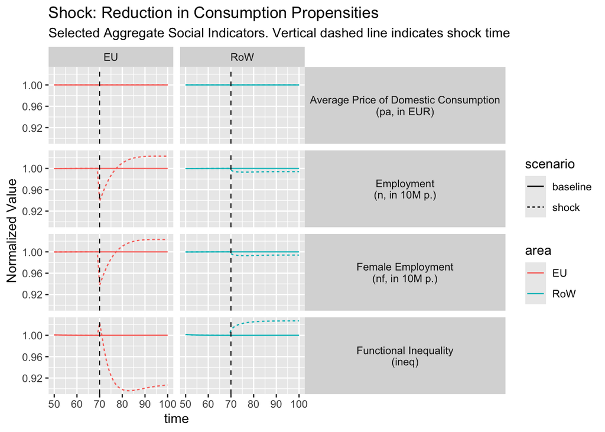

```r
print(p.social)
```

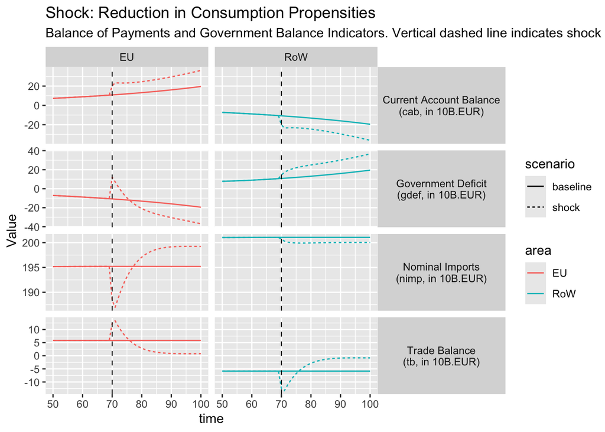

```r
print(p.external)
```